# Telecom Customer Retention | Joseph Thiongo

#l) plotting a distribution of tech support

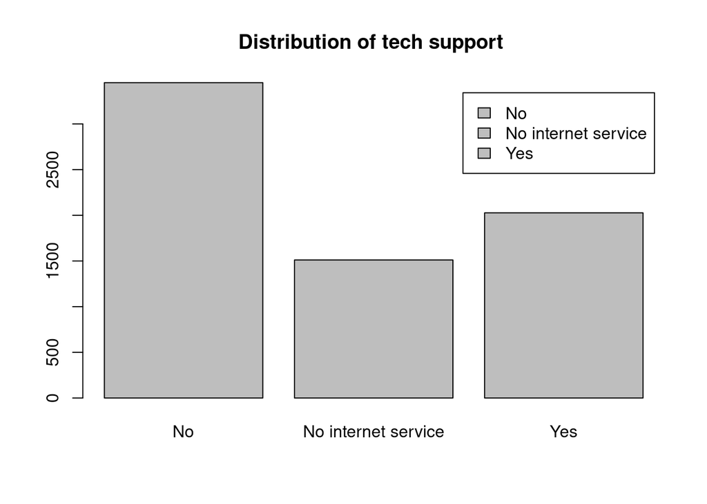

```r
tbl42 <- with(clean_df, table(techsupport))

barplot(tbl42, beside = TRUE, legend = TRUE, main = "Distribution of tech support ")
```

OBSERVATION::Subscribers who do not receive tech support make up almost half of the data set.

#m) plotting a distribution of streaming_tv

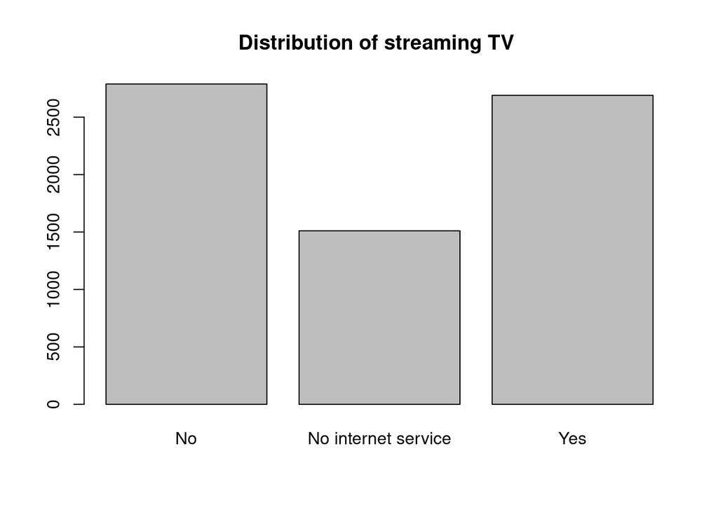

```r
tbl43 <- with(clean_df, table(streamingtv))

barplot(tbl43, beside = TRUE, main = "Distribution of streaming TV ")
```

#n) plotting a distribution of streaming movies

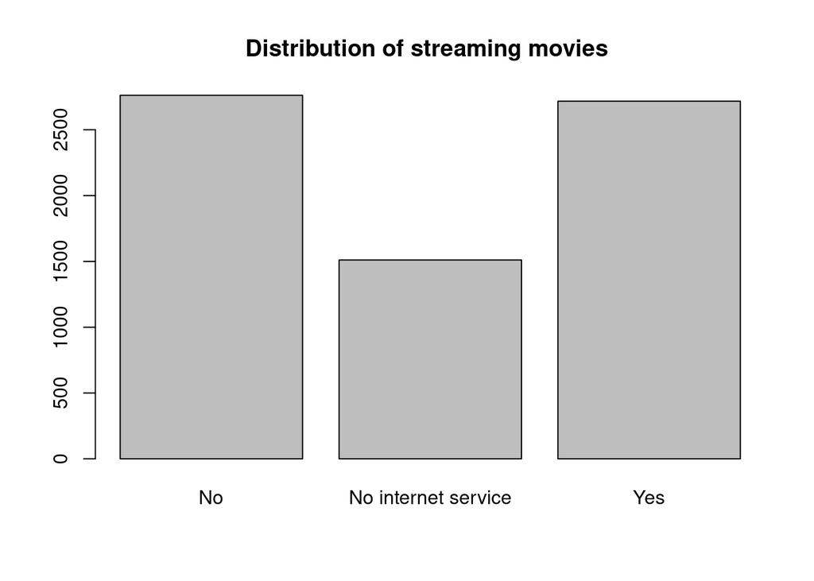

```r
tbl44 <- with(clean_df, table(streamingmovies))

barplot(tbl44, beside = TRUE, main = "Distribution of streaming movies ")
```

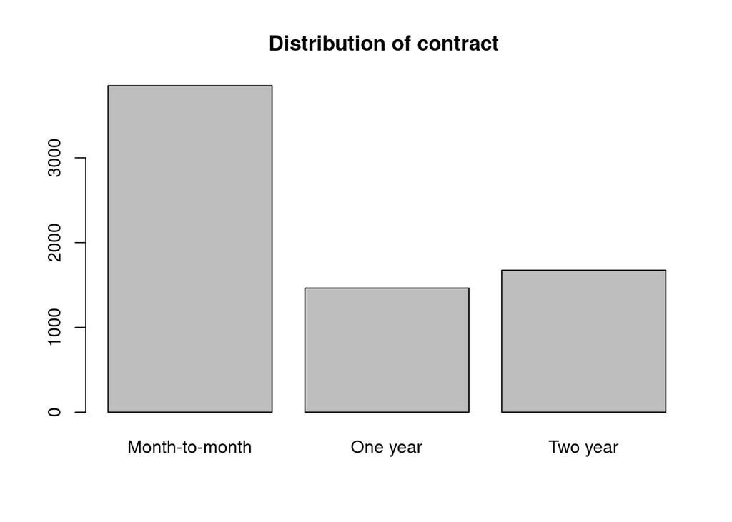

```r
tbl45 <- with(clean_df, table(contract))

barplot(tbl45, beside = TRUE, main = "Distribution of contract ")
```

OBSERVATION:: Majority of the subscribers are on month-to-month contracts, followed by two-year contracts, and then one-year contracts.

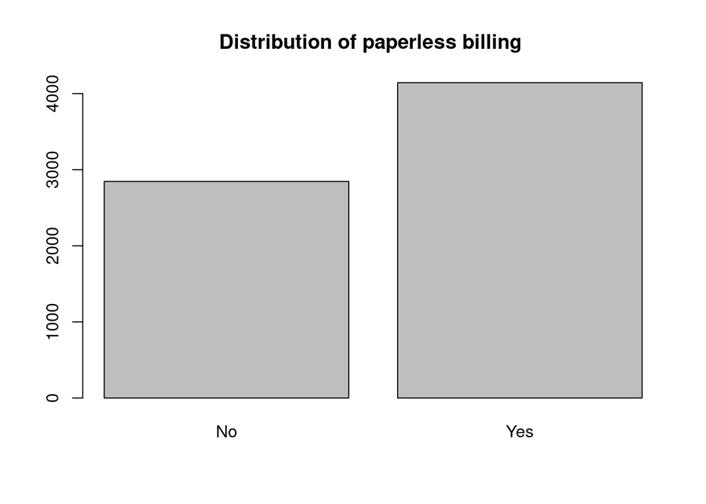

```r
tbl46 <- with(clean_df, table(paperlessbilling))

barplot(tbl46, beside = TRUE, main = "Distribution of paperless billing ")
```

OBSERVATION::Customers on paperless billing are the majority

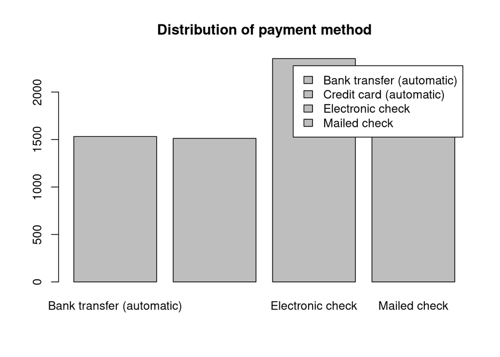

```r
tbl47 <- with(clean_df, table(paymentmethod))

barplot(tbl47, beside = TRUE, legend=TRUE, main = "Distribution of payment method")
```

OBSERVATION:: Electronic checks are the most popular form of payment while mailed checks, bank transfers, and credit cards are subsequently and similarly common.

#l) plotting a distribution of monthly charges

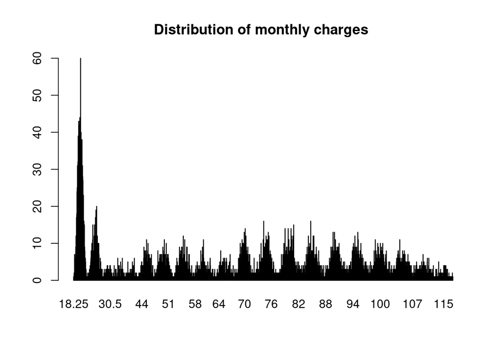

```r
tbl48 <- with(clean_df, table(monthlycharges))

barplot(tbl48, beside = TRUE, main = "Distribution of monthly charges ")
```

#m) we plot a distribution plot (kde) of total charges

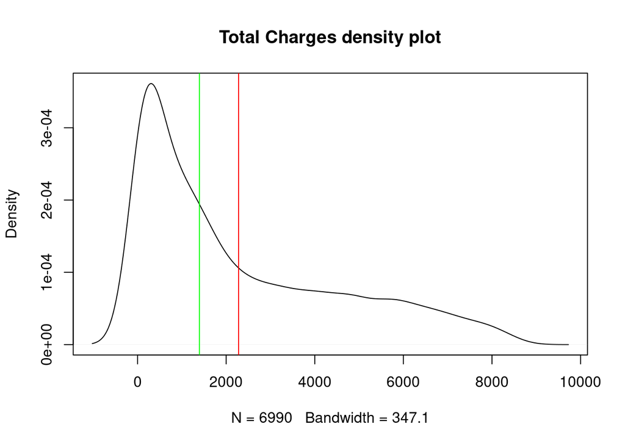

```r
tbl49 <- with(clean_df, table(totalcharges))

#barplot(tbl49, beside = TRUE, main = "Distribution of total charges ")
# Basic density
#p <- ggplot(clean_df, aes(x=totalcharges)) +
#  geom_density() + geom_vline(aes(xintercept=mean(totalcharges)),
#            color="blue", linetype="dashed", size=1)
#p

plot(density(clean_df$totalcharges), main="Total Charges density plot")

abline(v = mean(clean_df$totalcharges), col = "red")
abline(v = median(clean_df$totalcharges), col = "green")
```

OBSERVATION::Mean total charge is just above 2000/-. Bulk of customer total charges falls at 2000/- and below

#4. SUMMARY OF FINDINGS

Based on the results of the analysis, the following conclusions were arrived at:

1-There is no significant difference in churn rate between male and female subscribers. So this is not an area management needs to worry about. 2-Majority of the customers are not senior citizens so this makes this dataset biased and hard to identify whether being a senior citizen affects churn rate. 3-Not having a partner increases the likelihood of churning. 4-Not having dependents increases the likelihood of churning. 5-Having active phone service aids in customer retention 6-Customers on fiber optic internet service are most likely to churn 7-Customers without online security service have higher likelihood of churning 8-Customers without online backup service are more likely to churn 9-Customers without device protection more likely to churn than those who have device protection 10-Customers without techsupport are more likely to churn than those who have tech support

#5. Recommendations

In order to create an effective customer retention program, management should take the following measures:

1-Focus more on meeting the needs of non-senior citizens. 2-Focus more on having customers that have partners and/or dependents since these people are less likely to churn. Alternatively, management can come up with services specifically designed for customers without parters and/or dependents. This would require additional research. 3-Encourage customers to sign up for a phone service 4-Drill deeper into fiber customers’ service experience to determine why they have highest churn rate 5-Encourage customers to opt-in to the online security service 6-Encourage customers to opt-in to the online backup service 7-Bundle device protection along with online security or online backup service to enhance customer ‘stickiness’ 8-Add tech support to a bundled offering with other services to promote retention

#6. Challenging the Solution

#a). Did we have the right data? Do we need other data to answer our question?

As far as I can tell, we had the right data. However, more data is still needed, particularly those with more customers who churned so we can have a better understanding of why they might have churned.

#b). Did we have the right question? Yes, we did.